# Cyclistic Bike Share Analysis

Asif Dawood

2024-03-11

### Period March 2023 to Februrary 2024

### Introduction

In 2016, Cyclistic launched a successful bike-share offering. Since then, the program has grown to a fleet of 5,824 bicycles that are geotracked and locked into a network of 692 stations across Chicago. The bikes can be unlocked from one station and returned to any other station in the system anytime. Until now, Cyclistic’s marketing strategy relied on building general awareness and appealing to broad consumer segments. One approach that helped make these things possible was the flexibility of its pricing plans: single-ride passes, full-day passes, and annual memberships. Customers who purchase single-ride or full-day passes are referred to as casual riders. Customers who purchase annual memberships are Cyclistic members.Cyclistic’s finance analysts have concluded that annual members are much more profitable than casual riders.

### Case study

This report will examine the business question: ‘what is the most effective marketing strategy to converting Cyclistic’s casual riders to annul memberships?’ In order to achieve the above we would need to answer the following:

- How do annual members and casual riders use Cyclistic bikes differently?
- Why would casual riders buy Cyclistic annual memberships?
- How can Cyclistic use digital media to influence casual riders to become members?

This report will seek to deliver on the following objectives:

#### **How do annual members and casual riders use Cyclistic bikes differently?**

### Stakeholders

This includes:  
* Director of Marketing,  
* Cyclistic Marketing team,  
* Cyclistic Executive team

### Data sources

User data from the past 12 months, March 2023 - February 2024 has been made available. Each data set is in csv format and details every ride logged by Cyclistic customers. This data has been made publicly available via license by Motivate International Inc. All user’s personal data has been cleared for privacy.

### Documentation, cleaning and preparation of data for analysis

### Tools for analysis

R is being used due to the data size and visualizations needed to complete this analysis.

#### Import the Packages

```r
#install.packages("tidyverse")
#install.packages("lubridate")
```

#### Load the Packages

```r
library(tidyverse)
library(lubridate)
```

#### Import Data

```r
df_mar <- read_csv("./tripdata/202303-divvy-tripdata.csv")
df_apr <- read_csv("./tripdata/202304-divvy-tripdata.csv")
df_may <- read_csv("./tripdata/202305-divvy-tripdata.csv")
df_jun <- read_csv("./tripdata/202306-divvy-tripdata.csv")
df_jul <- read_csv("./tripdata/202307-divvy-tripdata.csv")
df_aug <- read_csv("./tripdata/202308-divvy-tripdata.csv")
df_sep <- read_csv("./tripdata/202309-divvy-tripdata.csv")
df_oct <- read_csv("./tripdata/202310-divvy-tripdata.csv")
df_nov <- read_csv("./tripdata/202311-divvy-tripdata.csv")
df_dec <- read_csv("./tripdata/202312-divvy-tripdata.csv")
df_jan <- read_csv("./tripdata/202401-divvy-tripdata.csv")
df_feb <- read_csv("./tripdata/202402-divvy-tripdata.csv")
```

#### Check Column names

```r
colnames(df_mar)
```

```
##  [1] "ride_id"            "rideable_type"      "started_at"
##  [4] "ended_at"           "start_station_name" "start_station_id"
##  [7] "end_station_name"   "end_station_id"     "start_lat"
## [10] "start_lng"          "end_lat"            "end_lng"
## [13] "member_casual"
```

```r
glimpse(df_mar)
```

```
## Rows: 258,678
## Columns: 13
## $ ride_id            <chr> "6842AA605EE9FBB3", "F984267A75B99A8C", "FF7CF57CFE…
## $ rideable_type      <chr> "electric_bike", "electric_bike", "classic_bike", "…
## $ started_at         <dttm> 2023-03-16 08:20:34, 2023-03-04 14:07:06, 2023-03-…
## $ ended_at           <dttm> 2023-03-16 08:22:52, 2023-03-04 14:15:31, 2023-03-…
## $ start_station_name <chr> "Clark St & Armitage Ave", "Public Rack - Kedzie Av…
## $ start_station_id   <chr> "13146", "491", "620", "TA1306000003", "18067", "62…
## $ end_station_name   <chr> "Larrabee St & Webster Ave", NA, "Clark St & Randol…
## $ end_station_id     <chr> "13193", NA, "TA1305000030", "13154", "TA1306000015…
## $ start_lat          <dbl> 41.91841, 41.97000, 41.89820, 41.88872, 41.91448, 4…
## $ start_lng          <dbl> -87.63645, -87.71000, -87.63754, -87.64445, -87.668…
## $ end_lat            <dbl> 41.92182, 41.95000, 41.88458, 41.91052, 41.88578, 4…
## $ end_lng            <dbl> -87.64414, -87.71000, -87.63189, -87.65311, -87.651…
## $ member_casual      <chr> "member", "member", "member", "member", "member", "…
```

#### Combining all the 12 months data

```r
df_trips <- rbind(df_mar,df_apr,df_may,df_jun,df_jul,df_aug,df_sep,df_oct,df_nov,df_dec,df_jan,df_feb)
```

#### Inspecting the data

```r
colnames(df_trips)
```

```
##  [1] "ride_id"            "rideable_type"      "started_at"
##  [4] "ended_at"           "start_station_name" "start_station_id"
##  [7] "end_station_name"   "end_station_id"     "start_lat"
## [10] "start_lng"          "end_lat"            "end_lng"
## [13] "member_casual"
```

```r
glimpse(df_trips)
```

```
## Rows: 5,707,168
## Columns: 13
## $ ride_id            <chr> "6842AA605EE9FBB3", "F984267A75B99A8C", "FF7CF57CFE…
## $ rideable_type      <chr> "electric_bike", "electric_bike", "classic_bike", "…
## $ started_at         <dttm> 2023-03-16 08:20:34, 2023-03-04 14:07:06, 2023-03-…
## $ ended_at           <dttm> 2023-03-16 08:22:52, 2023-03-04 14:15:31, 2023-03-…
## $ start_station_name <chr> "Clark St & Armitage Ave", "Public Rack - Kedzie Av…
## $ start_station_id   <chr> "13146", "491", "620", "TA1306000003", "18067", "62…
## $ end_station_name   <chr> "Larrabee St & Webster Ave", NA, "Clark St & Randol…
## $ end_station_id     <chr> "13193", NA, "TA1305000030", "13154", "TA1306000015…
## $ start_lat          <dbl> 41.91841, 41.97000, 41.89820, 41.88872, 41.91448, 4…
## $ start_lng          <dbl> -87.63645, -87.71000, -87.63754, -87.64445, -87.668…
## $ end_lat            <dbl> 41.92182, 41.95000, 41.88458, 41.91052, 41.88578, 4…
## $ end_lng            <dbl> -87.64414, -87.71000, -87.63189, -87.65311, -87.651…
## $ member_casual      <chr> "member", "member", "member", "member", "member", "…
```

```r
nrow(df_trips)
```

```
## [1] 5707168
```

```r
dim(df_trips)
```

```
## [1] 5707168      13
```

```r
head(df_trips)
```

```
## # A tibble: 6 × 13
##   ride_id          rideable_type started_at          ended_at
##   <chr>            <chr>         <dttm>              <dttm>
## 1 6842AA605EE9FBB3 electric_bike 2023-03-16 08:20:34 2023-03-16 08:22:52
## 2 F984267A75B99A8C electric_bike 2023-03-04 14:07:06 2023-03-04 14:15:31
## 3 FF7CF57CFE026D02 classic_bike  2023-03-31 12:28:09 2023-03-31 12:38:47
## 4 6B61B916032CB6D6 classic_bike  2023-03-22 14:09:08 2023-03-22 14:24:51
## 5 E55E61A5F1260040 electric_bike 2023-03-09 07:15:00 2023-03-09 07:26:00
## 6 123AAD676850F53C classic_bike  2023-03-22 17:47:02 2023-03-22 18:01:29
## # ℹ 9 more variables: start_station_name <chr>, start_station_id <chr>,
## #   end_station_name <chr>, end_station_id <chr>, start_lat <dbl>,
## #   start_lng <dbl>, end_lat <dbl>, end_lng <dbl>, member_casual <chr>
```

```r
str(df_trips)
```

```
## spc_tbl_ [5,707,168 × 13] (S3: spec_tbl_df/tbl_df/tbl/data.frame)
##  $ ride_id           : chr [1:5707168] "6842AA605EE9FBB3" "F984267A75B99A8C" "FF7CF57CFE026D02" "6B61B916032CB6D6" ...
##  $ rideable_type     : chr [1:5707168] "electric_bike" "electric_bike" "classic_bike" "classic_bike" ...
##  $ started_at        : POSIXct[1:5707168], format: "2023-03-16 08:20:34" "2023-03-04 14:07:06" ...
##  $ ended_at          : POSIXct[1:5707168], format: "2023-03-16 08:22:52" "2023-03-04 14:15:31" ...
##  $ start_station_name: chr [1:5707168] "Clark St & Armitage Ave" "Public Rack - Kedzie Ave & Argyle St" "Orleans St & Chestnut St (NEXT Apts)" "Desplaines St & Kinzie St" ...
##  $ start_station_id  : chr [1:5707168] "13146" "491" "620" "TA1306000003" ...
##  $ end_station_name  : chr [1:5707168] "Larrabee St & Webster Ave" NA "Clark St & Randolph St" "Sheffield Ave & Kingsbury St" ...
##  $ end_station_id    : chr [1:5707168] "13193" NA "TA1305000030" "13154" ...
##  $ start_lat         : num [1:5707168] 41.9 42 41.9 41.9 41.9 ...
##  $ start_lng         : num [1:5707168] -87.6 -87.7 -87.6 -87.6 -87.7 ...
##  $ end_lat           : num [1:5707168] 41.9 42 41.9 41.9 41.9 ...
##  $ end_lng           : num [1:5707168] -87.6 -87.7 -87.6 -87.7 -87.7 ...
##  $ member_casual     : chr [1:5707168] "member" "member" "member" "member" ...
##  - attr(*, "spec")=
##   .. cols(
##   ..   ride_id = col_character(),
##   ..   rideable_type = col_character(),
##   ..   started_at = col_datetime(format = ""),
##   ..   ended_at = col_datetime(format = ""),
##   ..   start_station_name = col_character(),
##   ..   start_station_id = col_character(),
##   ..   end_station_name = col_character(),
##   ..   end_station_id = col_character(),
##   ..   start_lat = col_double(),
##   ..   start_lng = col_double(),
##   ..   end_lat = col_double(),
##   ..   end_lng = col_double(),
##   ..   member_casual = col_character()
##   .. )
##  - attr(*, "problems")=<externalptr>
```

```r
summary(df_trips)
```

```
##    ride_id          rideable_type        started_at
##  Length:5707168     Length:5707168     Min.   :2023-03-01 00:00:50.00
##  Class :character   Class :character   1st Qu.:2023-06-06 07:50:54.75
##  Mode  :character   Mode  :character   Median :2023-08-03 18:06:17.00
##                                        Mean   :2023-08-09 14:41:47.23
##                                        3rd Qu.:2023-10-03 18:10:31.25
##                                        Max.   :2024-02-29 23:59:15.00
##
##     ended_at                      start_station_name start_station_id
##  Min.   :2023-03-01 00:04:17.00   Length:5707168     Length:5707168
##  1st Qu.:2023-06-06 08:04:30.00   Class :character   Class :character
##  Median :2023-08-03 18:23:45.00   Mode  :character   Mode  :character
##  Mean   :2023-08-09 15:00:06.02
##  3rd Qu.:2023-10-03 18:26:05.25
##  Max.   :2024-03-01 23:51:12.00
##
##  end_station_name   end_station_id       start_lat       start_lng
##  Length:5707168     Length:5707168     Min.   :41.63   Min.   :-87.94
##  Class :character   Class :character   1st Qu.:41.88   1st Qu.:-87.66
##  Mode  :character   Mode  :character   Median :41.90   Median :-87.64
##                                        Mean   :41.90   Mean   :-87.65
##                                        3rd Qu.:41.93   3rd Qu.:-87.63
##                                        Max.   :42.07   Max.   :-87.46
##
##     end_lat         end_lng       member_casual
##  Min.   : 0.00   Min.   :-88.16   Length:5707168
##  1st Qu.:41.88   1st Qu.:-87.66   Class :character
##  Median :41.90   Median :-87.64   Mode  :character
##  Mean   :41.90   Mean   :-87.65
##  3rd Qu.:41.93   3rd Qu.:-87.63
##  Max.   :42.18   Max.   :  0.00
##  NA's   :7353    NA's   :7353
```

#### Delete the individual data frames from memory

```r
rm(df_mar,df_apr,df_may,df_jun,df_jul,df_aug,df_sep,df_oct,df_nov,df_dec,df_jan,df_feb)
```

#### Checking the categorical columns

```r
table(df_trips$rideable_type)
```

```
##
##  classic_bike   docked_bike electric_bike
##       2732668         74354       2900146
```

```r
table(df_trips$member_casual)
```

```
##
##  casual  member
## 2047778 3659390
```

#### Adding columns for Data, Month, Year and day of week in to dataframe

```r
df_trips$date <- as.Date(df_trips$started_at)

df_trips$month <- format(df_trips$date,"%b")
df_trips$day <- format(df_trips$date, "%d")
df_trips$year <- format(df_trips$date,"%Y")
df_trips$day_of_week <- format(df_trips$date, "%A")
```

#### Getting the ride length and converting to numeric

```r
df_trips$ride_length <- difftime(df_trips$ended_at,df_trips$started_at)
df_trips$ride_length <-as.numeric(df_trips$ride_length)
```

```r
unique(df_trips$rideable_type)
```

```
## [1] "electric_bike" "classic_bike"  "docked_bike"
```

#### Removing not relevant columns

```r
df_trips <- df_trips %>%
  select(-c(start_lat, start_lng, end_lat, end_lng, start_station_id,end_station_id, end_station_name))
```

#### Removing docked_bikes and ride_length <60

```r
df_trips <- df_trips %>%
  filter( df_trips$rideable_type != "docked_bike" )

df_trips <- df_trips %>%
  filter(df_trips$ride_length >60)
```

#### Ordering the day of week

```r
df_trips$day_of_week <- ordered(df_trips$day_of_week,levels =c("Sunday", "Monday", "Tuesday", "Wednesday", "Thursday", "Friday", "Saturday"))
```

#### General statistics for members vs casual

```r
type_member_mean <- aggregate(df_trips$ride_length,list(df_trips$member_casual), mean)
type_member_max <- aggregate(df_trips$ride_length, list(df_trips$member_casual),max)
type_member_min <- aggregate(df_trips$ride_length,list(df_trips$member_casual), min)
type_member_mean
```

```
##   Group.1         x
## 1  casual 1384.4713
## 2  member  784.3691
```

```r
type_member_max
```

```
##   Group.1     x
## 1  casual 93596
## 2  member 93580
```

```r
type_member_min
```

```
##   Group.1  x
## 1  casual 61
## 2  member 61
```

#### Average ride time by member_type and week day

```r
member_day_mean <- aggregate(df_trips$ride_length, by =list(df_trips$member_casual, df_trips$day_of_week),mean)

colnames(member_day_mean) <- c("membership", "day_of_week", "average_trip_duration")
member_day_mean
```

```
##    membership day_of_week average_trip_duration
## 1      casual      Sunday             1631.0820
## 2      member      Sunday              874.3739
## 3      casual      Monday             1357.9780
## 4      member      Monday              745.5138
## 5      casual     Tuesday             1240.1053
## 6      member     Tuesday              759.8263
## 7      casual   Wednesday             1196.8357
## 8      member   Wednesday              755.7643
## 9      casual    Thursday             1205.5540
## 10     member    Thursday              750.1560
## 11     casual      Friday             1339.2146
## 12     member      Friday              776.1750
## 13     casual    Saturday             1561.4016
## 14     member    Saturday              869.4448
```

#### Total rides, mean duration, total duration by member type and day of week

```r
p <- df_trips %>%
  group_by(member_casual,day_of_week) %>%
  summarise(number_of_rides =n(), average_duration = round(mean(ride_length),0),total_duration = sum(ride_length)) %>%
  arrange(member_casual,day_of_week)
p
```

```
## # A tibble: 14 × 5
## # Groups:   member_casual [2]
##    member_casual day_of_week number_of_rides average_duration total_duration
##    <chr>         <ord>                 <int>            <dbl>          <dbl>
##  1 casual        Sunday               306447             1631      499840180
##  2 casual        Monday               218394             1358      296574242
##  3 casual        Tuesday              229162             1240      284185006
##  4 casual        Wednesday            235754             1197      282158812
##  5 casual        Thursday             258740             1206      311925037
##  6 casual        Friday               293199             1339      392656377
##  7 casual        Saturday             379213             1561      592103788
##  8 member        Sunday               388197              874      339429328
##  9 member        Monday               480830              746      358465424
## 10 member        Tuesday              554726              760      421495410
## 11 member        Wednesday            580999              756      439098290
## 12 member        Thursday             591658              750      443835782
## 13 member        Friday               516991              776      401275501
## 14 member        Saturday             452020              869      393006423
```

#### Plotting by count of rides

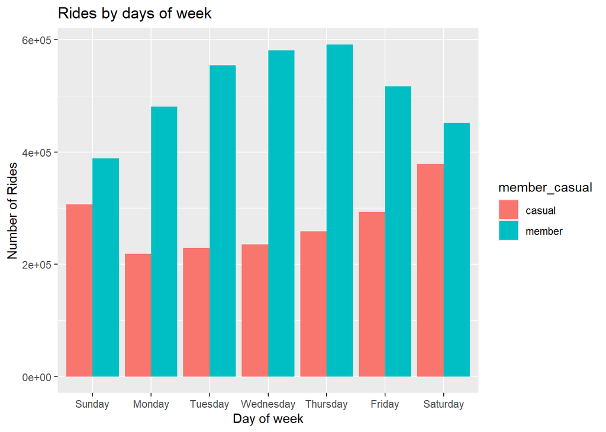

```r
p %>%
  ggplot(aes(x=day_of_week, y=number_of_rides, fill=member_casual))+
  geom_col(position = "dodge")+
  labs(title ="Rides by days of week",x="Day of week",y="Number of Rides" )
```

```r
ggsave("Rides by days of week.png")
```

#### Inference: The total no of rides by members are more that casual. Compartively the member rides on Weekends are lower than the rides on weekdays. While for casual riders the weekd end rides are more than the weekend rides. So the memeber rides will be one using their rides to go to their jobs.

#### Plotting by Average of ride duration

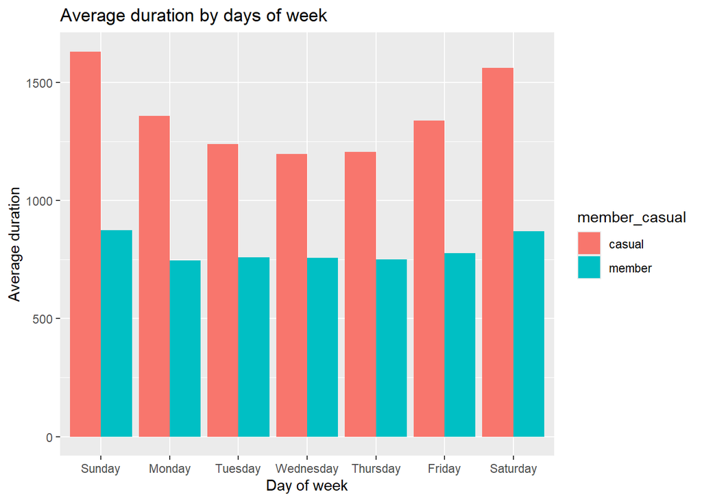

```r
p %>%
  ggplot(aes(x=day_of_week, y=average_duration, fill=member_casual))+
  geom_col(position = "dodge")+
  labs(title ="Average duration by days of week",x="Day of week",y="Average duration" )
```

```r
ggsave("Average duration by days of week.png")
```

#### Inference : The memebers average duration is less thoughout compared to the casual riders. Also the casual riders average distance on weekends are way higher than on the weekdays. So the casual riders averageduration is more even though their no of trips is less. It concludes that the casual riders use this for longer rides especially during weekends

#### Plotting by total duration of rides

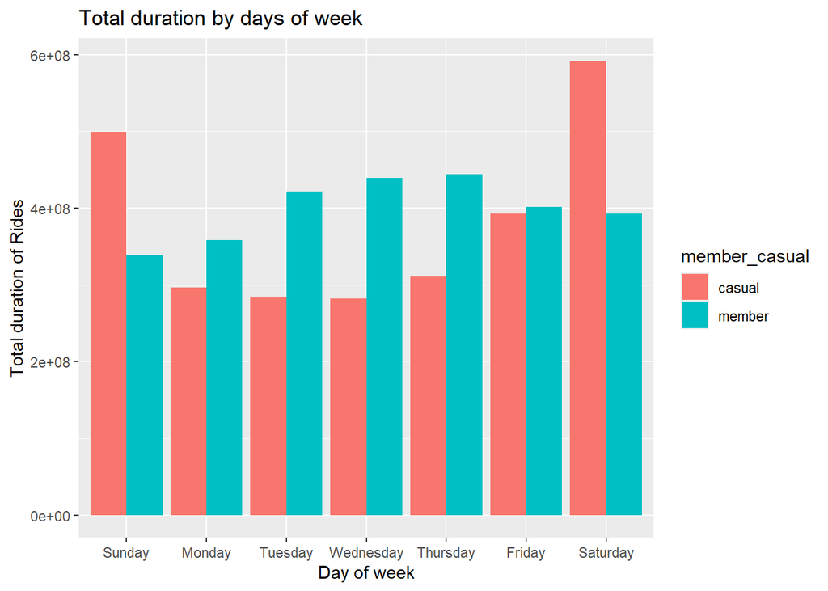

```r
p %>%
  ggplot(aes(x=day_of_week, y=total_duration, fill=member_casual))+
  geom_col(position = "dodge")+
  labs(title ="Total duration by days of week",x="Day of week",y="Total duration of Rides" )
```

```r
ggsave("Total duration by days of week.png")
```

#### Summarising total duration between member and casual and their percentages for Pie chart

```r
piedata <- df_trips %>%
  group_by(member_casual) %>%
  summarise(number_of_rides =n(), average_duration =round(mean(ride_length),0), total_duration =sum(ride_length))

piedata<- piedata %>%
  mutate(percent_number = round(number_of_rides/sum(number_of_rides) *100,0),
         percent_mean = round(average_duration / sum(average_duration) *100,0),
         percent_total= round(total_duration/sum(total_duration) * 100,0))

piedata
```

```
## # A tibble: 2 × 7
##   member_casual number_of_rides average_duration total_duration percent_number
##   <chr>                   <int>            <dbl>          <dbl>          <dbl>
## 1 casual                1920909             1384     2659443442             35
## 2 member                3565421              784     2796606158             65
## # ℹ 2 more variables: percent_mean <dbl>, percent_total <dbl>
```

#### Setting up the color palette

```r
# Setting the color
library(RColorBrewer)
myPalette <- brewer.pal(3, "Set1")
```

#### Pie chart comparing number of rides

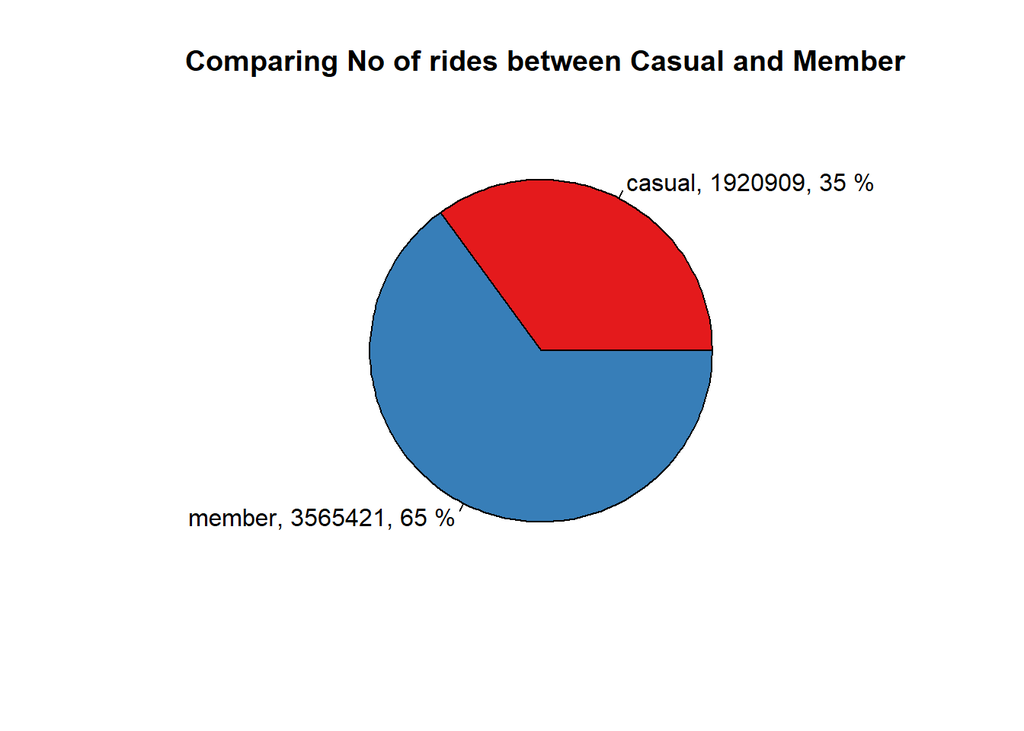

```r
lbls<-paste(piedata$percent_number,"%")
lbls <- paste(piedata$member_casual,piedata$number_of_rides,lbls, sep= ", ")
pie(piedata$number_of_rides, labels = lbls, col=myPalette, main = " Comparing No of rides between Casual and Member")
```

#### Inference: The no of casual riders is 35% and memener riders are 65%

#### Comparing average duration between Casual and Member

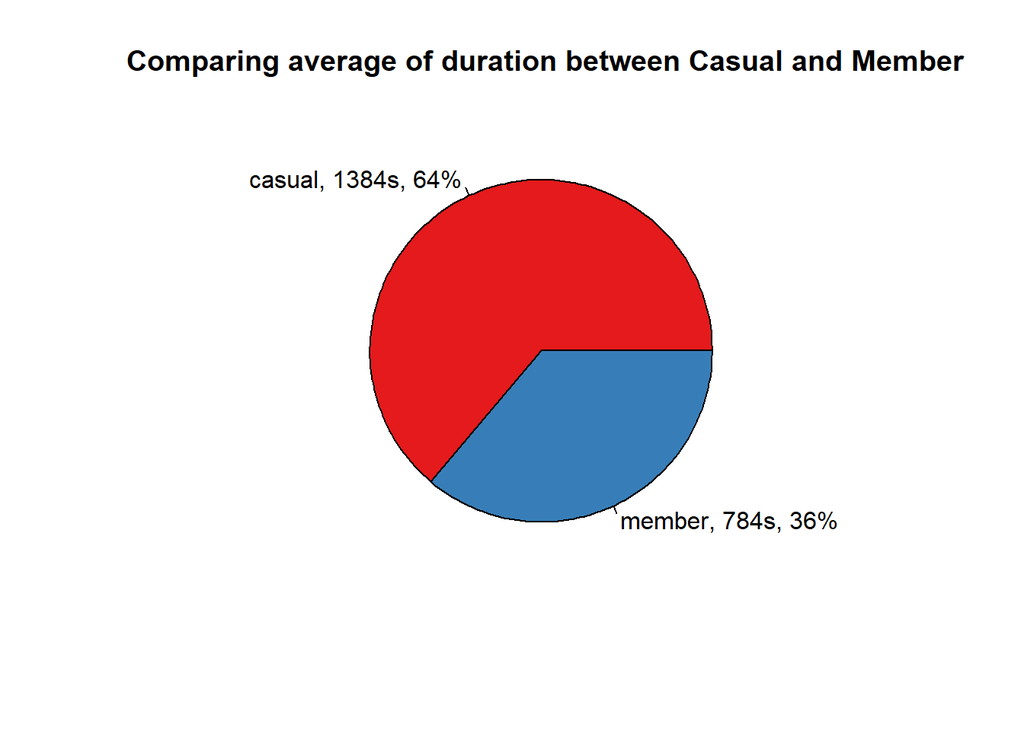

```r
lbls1= paste(piedata$average_duration,"s", sep="")
lbls2=paste(piedata$percent_mean,"%", sep="")
lbls <- paste(piedata$member_casual,lbls1,lbls2, sep= ", ")
pie(piedata$average_duration, labels = lbls, col=myPalette, main = " Comparing average of duration between Casual and Member")
```

#### Comparing total duration betwen casual and member

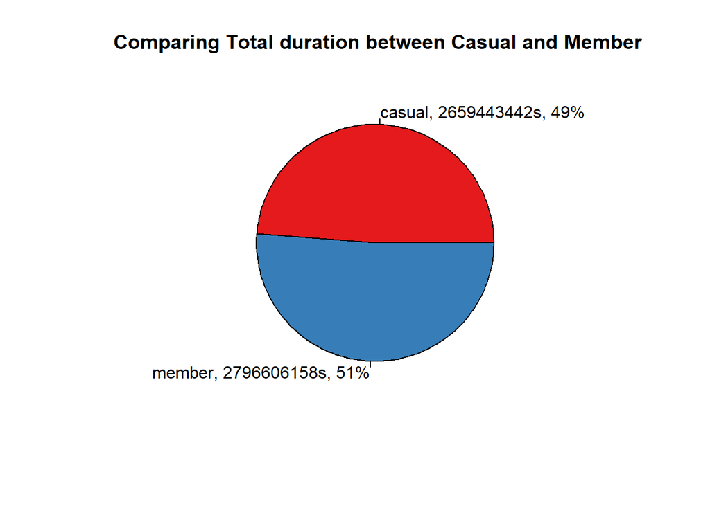

```r
lbls1= paste(piedata$total_duration,"s", sep="")
lbls2=paste(piedata$percent_total,"%", sep="")
lbls <- paste(piedata$member_casual,lbls1,lbls2, sep= ", ")
pie(piedata$total_duration, labels = lbls, col=myPalette, main = " Comparing Total duration between Casual and Member")
```

#### Inference: But when it comes total duration , Both are nearly same

#### Find long rides greater than one day and summarisation

```r
long_rides <- df_trips[(df_trips$ride_length >= 86400),]

p_long <- df_trips %>%
  filter(ride_length>=86400) %>%
  group_by(member_casual) %>%
  summarise(number_of_rides =n(), average_druation = round(mean(ride_length),0),total_duration = sum(ride_length)) %>%
  arrange(member_casual)

p_long
```

```
## # A tibble: 2 × 4
##   member_casual number_of_rides average_druation total_duration
##   <chr>                   <int>            <dbl>          <dbl>
## 1 casual                   4055            89958      364777844
## 2 member                   1445            89953      129981668
```

#### Plot count of no of rides greater than 1 day

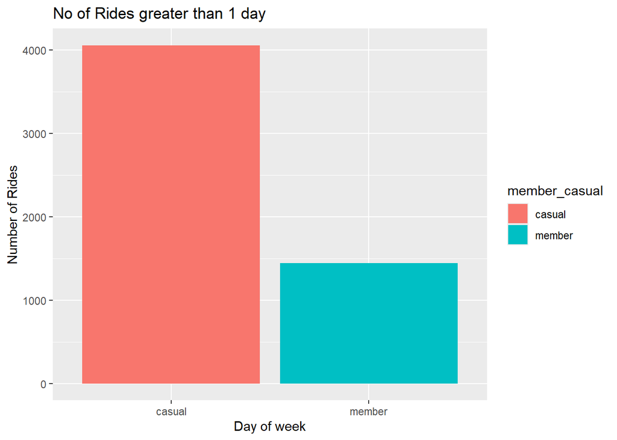

```r
p_long %>%
  ggplot(aes(x=member_casual, y=number_of_rides, fill=member_casual))+
  geom_col(position = "dodge")+
  labs(title ="No of Rides greater than 1 day",x="Day of week",y="Number of Rides" )
```

```r
ggsave("No of Rides greater than 1 day.png")
```

#### Plot total duration of rides greater than 1 day

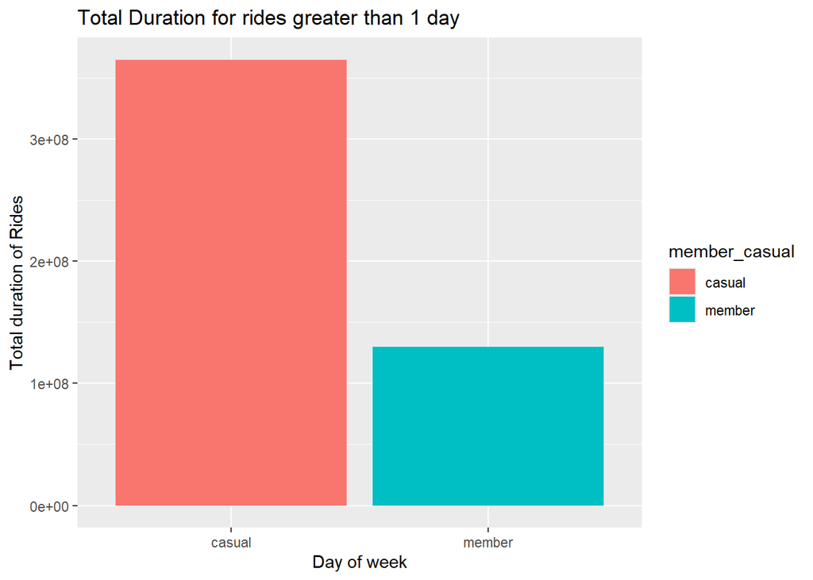

```r
p_long %>%
  ggplot(aes(x=member_casual, y=total_duration, fill=member_casual))+
  geom_col(position = "dodge")+
  labs(title ="Total Duration for rides greater than 1 day",x="Day of week",y="Total duration of Rides" )
```

```r
ggsave("Total Duration for rides greater than 1 day.png")
```

#### Order by Month name

```r
df_trips$month <- ordered(df_trips$month,levels =c("Jan", "Feb", "Mar", "Apr", "May", "Jun","Jul","Aug","Sep", "Oct","Nov", "Dec"))
```

#### Trips by months

```r
p_month <- df_trips %>%
  group_by(member_casual,month) %>%
  summarise(number_of_rides =n(), average_duration = round(mean(ride_length),0),total_duration = sum(ride_length)) %>%
  arrange(member_casual,month)
p_month
```

```
## # A tibble: 24 × 5
## # Groups:   member_casual [2]
##    member_casual month number_of_rides average_duration total_duration
##    <chr>         <ord>           <int>            <dbl>          <dbl>
##  1 casual        Jan             23768             1315       31249671
##  2 casual        Feb             46238             1541       71258592
##  3 casual        Mar             57270              976       55879961
##  4 casual        Apr            133682             1255      167802829
##  5 casual        May            214342             1373      294214085
##  6 casual        Jun            278142             1356      377094267
##  7 casual        Jul            304207             1435      436521838
##  8 casual        Aug            287836             1418      408200968
##  9 casual        Sep            255691             1546      395187634
## 10 casual        Oct            172909             1405      242867448
## # ℹ 14 more rows
```

#### Plot the number of rides by month and member_casual

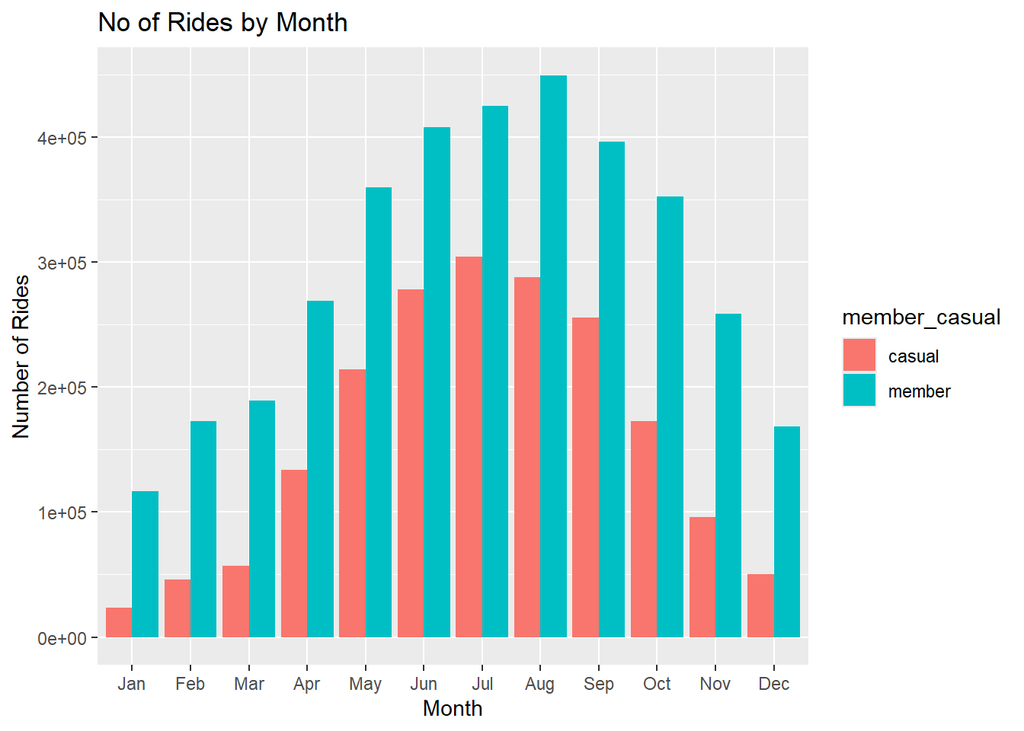

```r
p_month %>%
  ggplot(aes(x=month, y=number_of_rides, fill=member_casual))+
  geom_col(position = "dodge")+
  labs(title ="No of Rides by Month",x="Month",y="Number of Rides" )
```

```r
ggsave("No of Rides by Month.png")
```

#### Inference: the no of rides by memebers are more than than the casual ones. the rides peak through the summer months and at the lowest during the Dec-Jan months due to the extrem winter perhaps

#### Plot the average duration of rides by month and member_casual

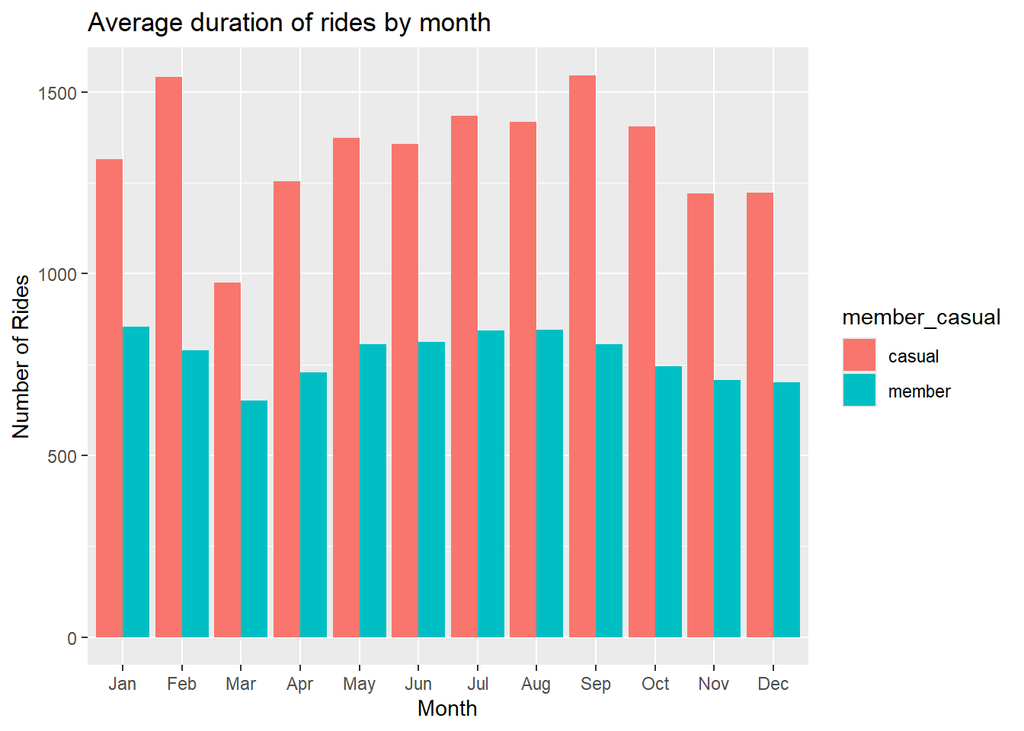

```r
p_month %>%
  ggplot(aes(x=month, y=average_duration, fill=member_casual))+
  geom_col(position = "dodge")+
  labs(title ="Average duration of rides by month",x="Month",y="Number of Rides" )
```

```r
ggsave("Average duration of rides by month.png")
```

#### Inference: But when it comes ta average duration , the casual riders are more than the memebers

#### Plot the total duration of rides by month and member_casual

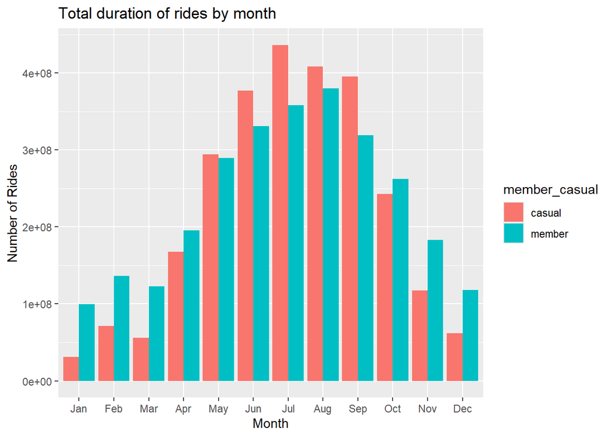

```r
p_month %>%
  ggplot(aes(x=month, y=total_duration, fill=member_casual))+
  geom_col(position = "dodge")+
  labs(title ="Total duration of rides by month",x="Month",y="Number of Rides" )
```

```r
ggsave("Total duration of rides by month.png")
```

#### summarising the data by rideable_type and memeber type

```r
p_type<- df_trips %>%
  group_by(member_casual,rideable_type) %>%
  summarise(number_of_rides =n(), average_duration = round(mean(ride_length),0),total_duration = sum(ride_length)) %>%
  arrange(member_casual,rideable_type)
 p_type
```

```
## # A tibble: 4 × 5
## # Groups:   member_casual [2]
##   member_casual rideable_type number_of_rides average_duration total_duration
##   <chr>         <chr>                   <int>            <dbl>          <dbl>
## 1 casual        classic_bike           873103             1976     1725408545
## 2 casual        electric_bike         1047806              891      934034897
## 3 member        classic_bike          1817276              869     1580100644
## 4 member        electric_bike         1748145              696     1216505514
```

#### Plotting the number of rides by Ride type

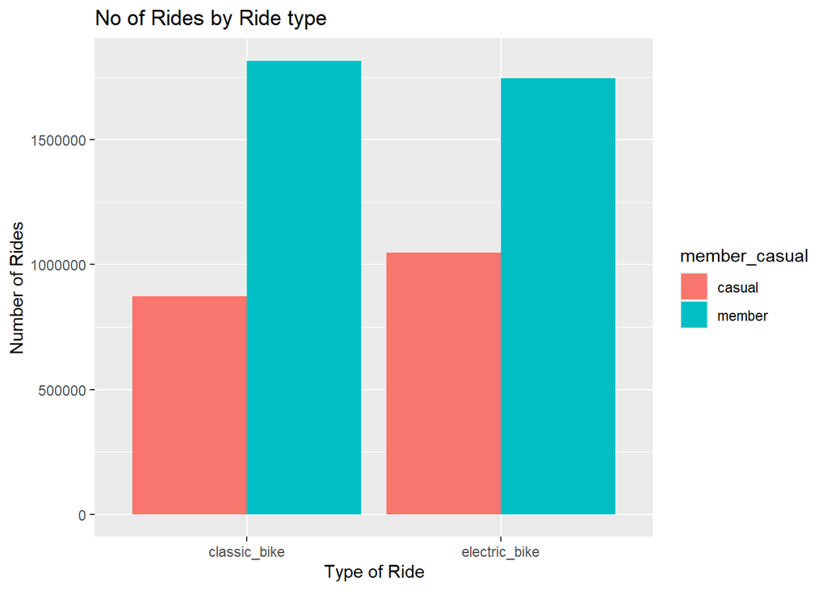

```r
p_type %>%
 ggplot(aes(x=rideable_type, y=number_of_rides, fill=member_casual))+
  geom_col(position = "dodge")+
  labs(title ="No of Rides by Ride type",x="Type of Ride",y="Number of Rides" )
```

```r
ggsave("No of Rides by Ride type.png")
```

#### Inference: Casual members use more of electric bike than classic bike. while the memebers are more or less same when it comes to type of bike

#### Plotting the total duration by Ride type

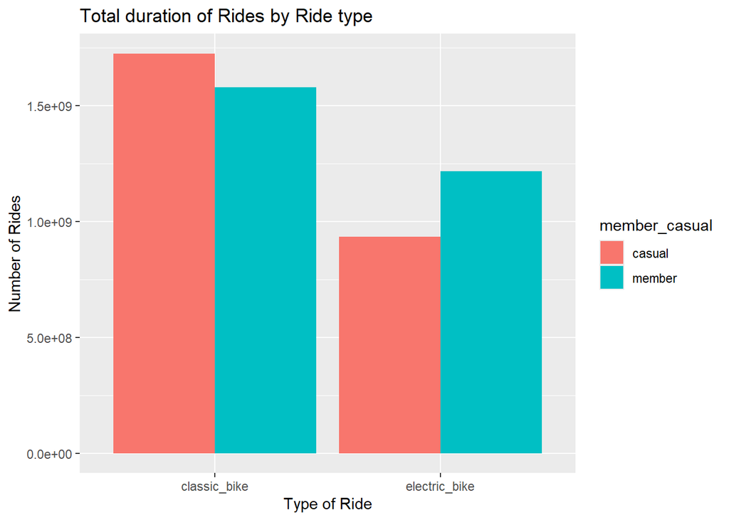

```r
p_type %>%
 ggplot(aes(x=rideable_type, y=total_duration, fill=member_casual))+
  geom_col(position = "dodge")+
  labs(title ="Total duration of Rides by Ride type",x="Type of Ride",y="Number of Rides" )
```

```r
ggsave("Total duration of Rides by Ride type.png")
```

#### Inference: The duration of ride is more for casual bike than the electric ones

#### Summarising by Ride types

```r
p_type1<- df_trips %>%
  group_by(rideable_type) %>%
  summarise(number_of_rides =n(), average_duration = round(mean(ride_length),0),total_duration = sum(ride_length)) %>%
  mutate(percent_number = round(number_of_rides /sum(number_of_rides)*100,0))


 p_type1
```

```
## # A tibble: 2 × 5
##   rideable_type number_of_rides average_duration total_duration percent_number
##   <chr>                   <int>            <dbl>          <dbl>          <dbl>
## 1 classic_bike          2690379             1229     3305509189             49
## 2 electric_bike         2795951              769     2150540411             51
```

#### Plotting pie chart showing the count of trips by rideable type

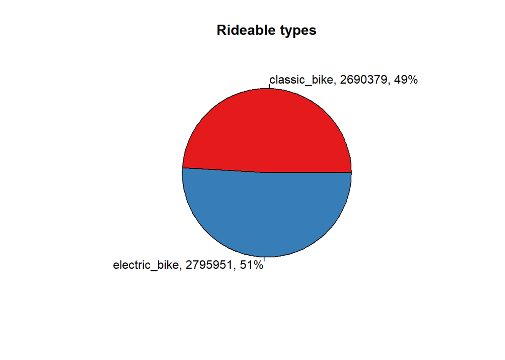

```r
lbls1= paste(p_type1$number_of_rides, sep="")
lbls2=paste(p_type1$percent_number,"%", sep="")
lbls <- paste(p_type1$rideable_type,lbls1,lbls2, sep= ", ")
pie(p_type1$number_of_rides, labels = lbls, col=myPalette, main = "Rideable types")
```

#### Inference :The usage in number of trips are more or less same by the bike type

### Conclusion

1. The casual riders ride more on weekends while the members ride more on weekdays.
2. Also the the longer rides are usually taken by casual riders

### Recommendation

1. Incentives can be given to Casual riders who take the bike for longer duration who convert to members
2. Weekend special deals can be given for members so that the casual will be encouraged to join the member program